# Advanced Graphics

### 2.3.7 Themes

The ggplot2 theme system does not affect how the data is rendered by geoms, or how it is transformed by scales. Themes don’t change the perceptual properties of the plot, but they do help you make the plot aesthetically pleasing or match an existing style guide. Themes give you control over things like fonts, ticks, panel strips, and backgrounds.

The theming system is composed of four main components:

- Theme **elements** specify the non-data elements that you can control. For example, the `plot.title()` element controls the appearance of the plot title;
- Each element is associated with an **element function**, which describes the visual properties of the element. For example, `element_text()` sets the font size, colour and face of text elements like `plot.title()`.
- The `theme()` function which allows you to override the default theme elements by calling element functions, like `theme(plot.title = element_text(colour = "red"))`.
- Complete themes, like `theme_grey()` set all of the theme elements to values designed to work together harmoniously.

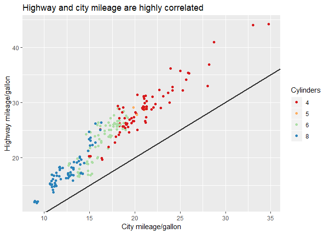

```r
# Figure 53
base <- ggplot(mpg, aes(cty, hwy, colour = factor(cyl))) +
  geom_jitter() +
  geom_abline(colour = "black", size = 1, alpha = 0.8) +
  labs(x = "City mileage/gallon",
       y = "Highway mileage/gallon",
       colour = "Cylinders",
       title = "Highway and city mileage are highly correlated") +
  scale_colour_brewer(type = "seq", palette = "Spectral")
print(base)
```

Next, you need to make sure the plot matches the style guidelines of your journal: 1. The background should be white, not pale grey. 2. The legend should be placed inside the plot if there’s room. 3. Major gridlines should be a pale grey and minor gridlines should be removed. 4. The plot title should be 12pt bold text and centered.

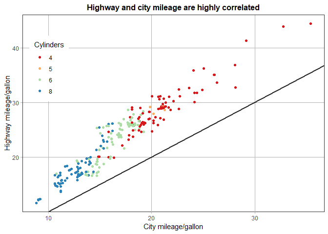

```r
# Figure 54
style <- theme(plot.title = element_text(face = "bold", size = 12, hjust = 0.5),
        legend.background = element_rect(fill = "white", size = 2, colour = "white"),
        legend.justification = c(0.6, 0.1),
        legend.position = c(0.1, 0.6),
        axis.ticks = element_line(colour = "grey70", size = 0.2),
        panel.grid.major = element_line(colour = "grey70", size = 0.2),
        panel.grid.minor = element_blank())
base + theme_bw() + style
```

There are seven other themes built in to ggplot2 1.1.0:

- `theme_grey()`: a light grey background and white gridlines.
- `theme_bw()` : a white background and thin grey grid lines.
- `theme_linedraw()`: A theme with only black lines of various widths on white backgrounds, reminiscent of a line drawing
- `theme_light()`: similar to theme_linedraw() but with light grey lines and axes, to direct more attention towards the data.
- `theme_dark()`: the dark cousin of theme_light(), with similar line sizes but a dark background. Useful to make thin coloured lines pop out.
- `theme_minimal()`: A minimalistic theme with no background annotations.
- `theme_classic()`: A classic-looking theme, with x and y axis lines and no gridlines.
- `theme_void()`: A completely empty theme.

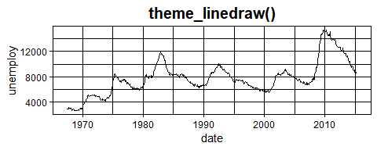

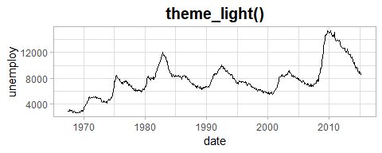

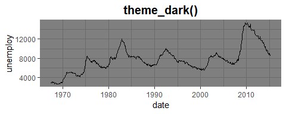

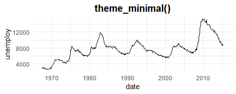

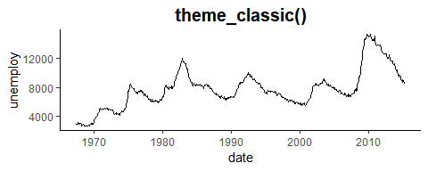

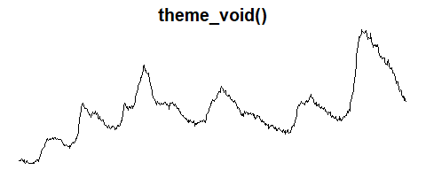

As well as applying themes a plot at a time, you can change the default theme with `theme_set()`. For example, if you really hate the default grey background, run `theme_set(theme_bw())` to use a white background for all plots.

To modify an individual theme component you use code like `plot + theme(element.name = element_function())`. There are four basic types of built-in element functions: text, lines, rectangles, and blank. Each element function has a set of parameters that control the appearance:

- `element_text()` draws labels and headings. You can control the font family, face, colour, size (in points), hjust, vjust, angle (in degrees) and lineheight (as ratio of fontcase).
- `element_line()` draws lines parameterised by colour, size and linetype.
- `element_rect()` draws rectangles, mostly used for backgrounds, parameterised by fill colour and border colour, size and linetype.
- `element_blank()` draws nothing. Use this if you don’t want anything drawn, and no space allocated for that element

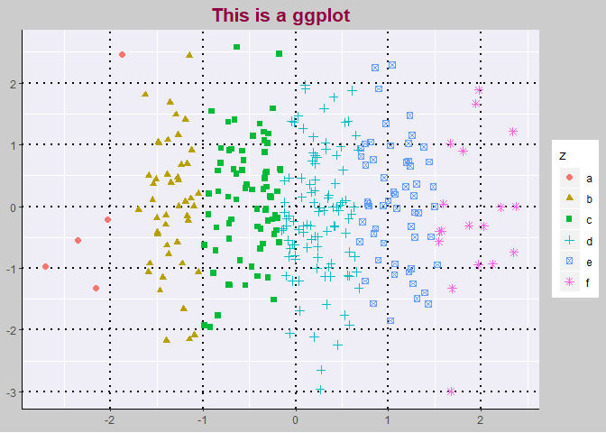

```r
# Figure 55
df <- data.frame(x = rnorm(300), y = rnorm(300))
df$z <- cut(df$x, 6, labels = c("a", "b", "c", "d", "e", "f"))
ggplot(df, aes(x, y)) +
  geom_point(aes(colour = z, shape = z), size = 2) +
  labs(title = "This is a ggplot") +
  xlab(NULL) +
  ylab(NULL) +
  theme(plot.title = element_text(face = "bold", colour = "#91003F", size = 16, hjust = 0.5),
        panel.grid.major = element_line(colour = "black", linetype = "dotted", size = 1),
        plot.background = element_rect(fill = "grey80", colour = NA),
        panel.background = element_rect(fill = "#EFEDF5"),
        axis.line = element_line(colour = "black"))
```

#### 2.3.7.1 Legend Elements

| Element | Setter | Description |
| --- | --- | --- |
| legend.background | element_rect() | legend background |
| legend.key | element_rect() | background of legend keys |
| legend.key.size | unit() | legend key size |
| legend.key.height | unit() | legend key height |
| legend.key.width | unit() | legend key width |
| legend.margin | unit() | legend margin |
| legend.text | element_text() | legend labels |
| legend.text.align | 0, 1 | legend label alignment (0 = right, 1 = left) |
| legend.title | element_text() | legend name |
| legend.title.align | 0, 1 | legend name alignment (0 = right, 1 = left) |

The legend elements control the apperance of all legends. We can also modify the appearance of individual legends by modifying these elements.

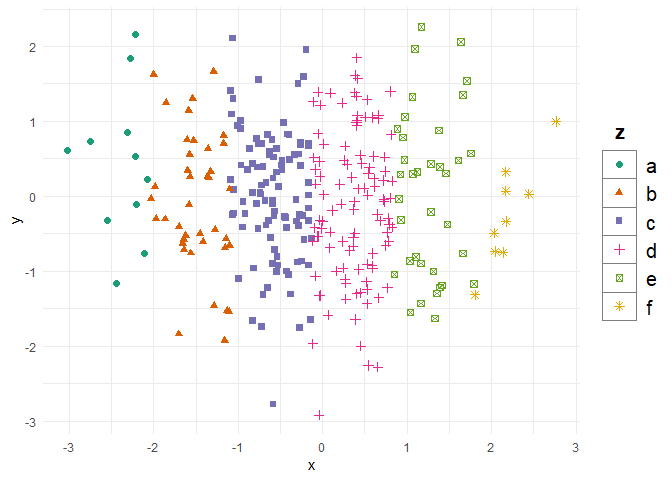

```r
# Figure 56
df <- data.frame(x = rnorm(300), y = rnorm(300))
df$z <- cut(df$x, 6, labels = c("a", "b", "c", "d", "e", "f"))
ggplot(df, aes(x, y)) +
  geom_point(aes(colour = z, shape = z), size = 2) +
  theme_minimal() +
  scale_colour_brewer(type = "seq", palette = "Dark2") +
  theme(legend.key = element_rect(color = "grey50"),
        legend.key.width = unit(0.9, "cm"),
        legend.key.height = unit(0.75, "cm"),
        legend.text = element_text(size = 15),
        legend.title = element_text(size = 15, face = "bold"),
        legend.title.align = 0.3)
```

#### 2.3.7.2 Panel Elements

| Element | Setter | Description |
| --- | --- | --- |
| panel.background | element_rect() | panel background (under data) |
| panel.border | element_rect() | panel border (over data) |
| panel.grid.major | element_line() | major grid lines |
| panel.grid.major.x | element_line() | vertical major grid lines |
| panel.grid.major.y | element_line() | horizontal major grid lines |
| panel.grid.minor | element_line() | minor grid lines |
| panel.grid.minor.x | element_line() | vertical minor grid lines |
| panel.grid.minor.y | element_line() | horizontal minor grid lines |
| aspect.ratio | numeric plot | aspect ratio |

Panel elements control the appearance of the plotting panels. You can also modify the appearance of panel by modifying these elements.

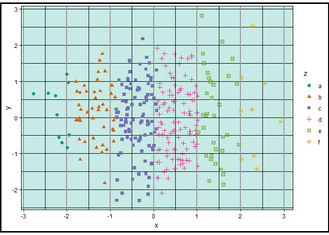

```r
# Figure 57
df <- data.frame(x = rnorm(300), y = rnorm(300))
df$z <- cut(df$x, 6, labels = c("a", "b", "c", "d", "e", "f"))
ggplot(df, aes(x, y)) +
  geom_point(aes(colour = z, shape = z), size = 2) +
  theme_linedraw() +
  scale_colour_brewer(type = "seq", palette = "Dark2") +
  theme(panel.background = element_rect(fill = "#C7EAE5"),
        panel.grid.major.x = element_line(color = "gray60", size = 0.8),
        plot.background = element_rect(colour = "black", size = 2),
        aspect.ratio = 12 / 16)
```

#### 2.3.7.3 Facetting Elements

| Element | Setter | Description |
| --- | --- | --- |
| strip.background | element_rect() | background of panel strips |
| strip.text | element_text() | strip text |
| strip.text.x | element_text() | horizontal strip text |
| strip.text.y | element_text() | vertical strip text |
| panel.margin | unit() | margin between facets |
| panel.margin.x | unit() | margin between facets (vertical) |
| panel.margin.y | unit() | margin between facets (horizontal) |

The above theme elements are associated with faceted ggplots.

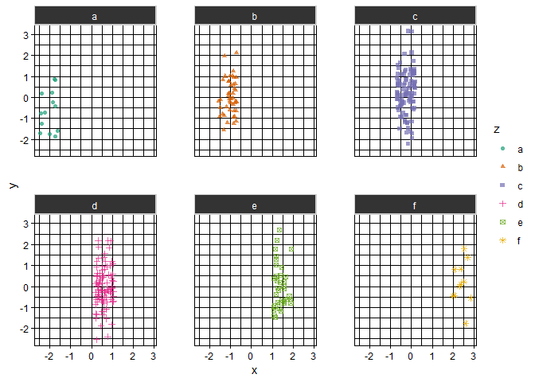

```r
# Figure 58
df <- data.frame(x = rnorm(300), y = rnorm(300))
df$z <- cut(df$x, 6, labels = c("a", "b", "c", "d", "e", "f"))
ggplot(df, aes(x, y)) +
  geom_point(aes(colour = z, shape = z), alpha = 0.7) +
  theme_linedraw() +
  scale_colour_brewer(type = "seq", palette = "Dark2") +
  facet_wrap(~z) +
  theme(panel.spacing = unit(0.5, "in"),
        strip.background = element_rect(fill = "grey20", color = "grey80", size = 1),
        strip.text = element_text(colour = "white"))
```

### 2.3.8 Colour

In R, a colour is represented as a string. Basically, a colour is defined, like in HTML/CSS, using the hexadecimal values (00 to FF) for red, green, and blue, concatenated into a string, prefixed with a “#”. A pure red colour this is represented with “#FF0000”.

Besides the “#RRGGBB” RGB colour strings, one can also use one of R’s predefined named colours in R package–**RColorBrewer**

#### 2.3.8.1 Key Color Functions

First, let’ s see some key ggplot2 R functions for changing a plot color.

1. Set ggplot color manually:
- `scale_fill_manual()` for box plot, bar plot, violin plot, dot plot, etc
- `scale_color_manual()` or `scale_colour_manual()` for lines and points
2. Use colorbrewer palettes:
- `scale_fill_brewer()` for box plot, bar plot, violin plot, dot plot, etc
- `scale_color_brewer()` or `scale_colour_brewer()` for lines and points
3. Use grey color scales:
- `scale_fill_grey()` for box plot, bar plot, violin plot, dot plot, etc
- `scale_colour_grey()` or `scale_colour_brewer()` for points, lines, etc
4. Change the default ggplot gradient color:
- `scale_color_gradient()`, `scale_fill_gradient()` for sequential gradients between two colors
- `scale_color_gradient2()`, `scale_fill_gradient2()` for diverging gradients
- `scale_color_gradientn()`, `scale_fill_gradientn()` for gradient between n colors

This is the default color:

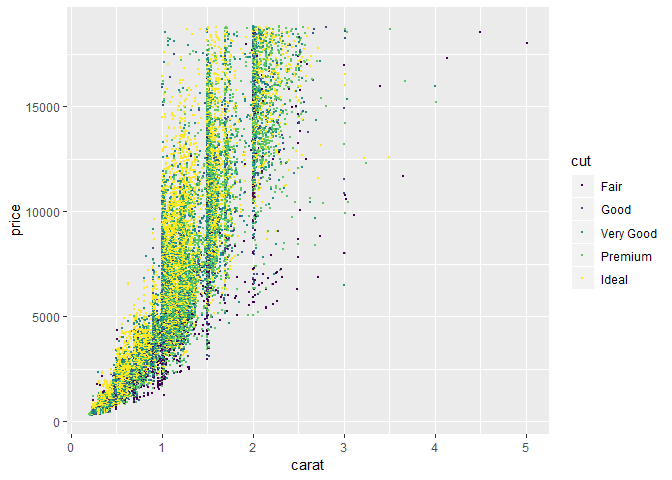

```r
# Figure 59
ggplot(diamonds, aes(carat, price, colour = cut)) +
  geom_point(size = 0.5)
```

Set custom color palettes:

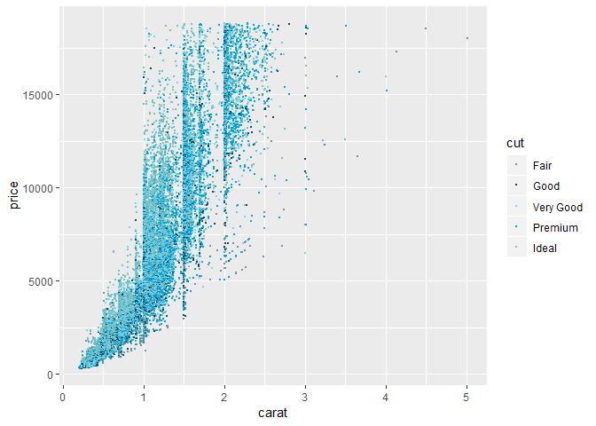

```r
# Figure 60
ggplot(diamonds, aes(carat, price, colour = cut)) +
  geom_point(size = 0.5) +
  scale_colour_manual(values = c("#6794a7", "#014d64", "#7ad2f6", "#01a2d9", "#76c0c1"))
```

Using palette in RColorBrewer:

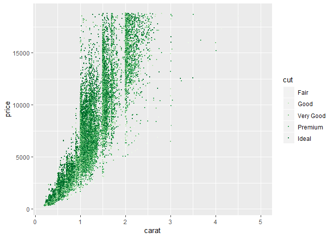

```r
# Figure 61
library(RColorBrewer)
ggplot(diamonds, aes(carat, price, colour = cut)) +
  geom_point(size = 0.5) +
  scale_colour_brewer(palette = "Greens")
```

Using grey color scales:

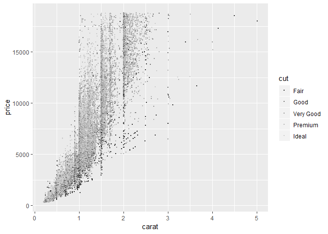

```r
# Figure 62
ggplot(diamonds, aes(carat, price, colour = cut)) +
  geom_point(size = 0.5) +
  scale_colour_grey()
```

When data is splitted by a continuous variable:

Sequential gradients between two colors

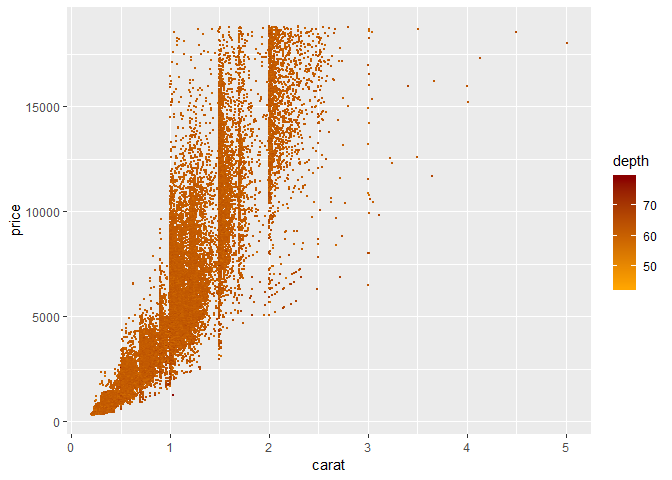

```r
# Figure 63
ggplot(diamonds, aes(carat, price, colour = depth)) +
  geom_point(size = 0.5)+
  scale_colour_gradient(low = "orange", high = "Darkred")
```

Diverge gradients

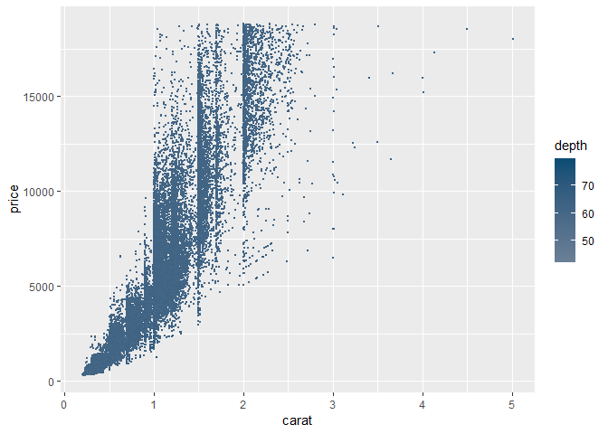

```r
# Figure 64
ggplot(diamonds, aes(carat, price, colour = depth)) +
  geom_point(size = 0.5) +
  scale_colour_gradient2(low="#8E0F2E", mid="#BFBEBE", high="#0E4E75")
```

#### 2.3.8.2 Predefined Color Palettes in RColorBrewer and ggplot2

Second, we’ll see some predefined color palettes in R package. The most commonly used color scales are Colorbrewer palettes [RColorBrewer package] and Grey color palettes [ggplot2 package].

- Show all colorbrewer palettes in RColorBrewer package:

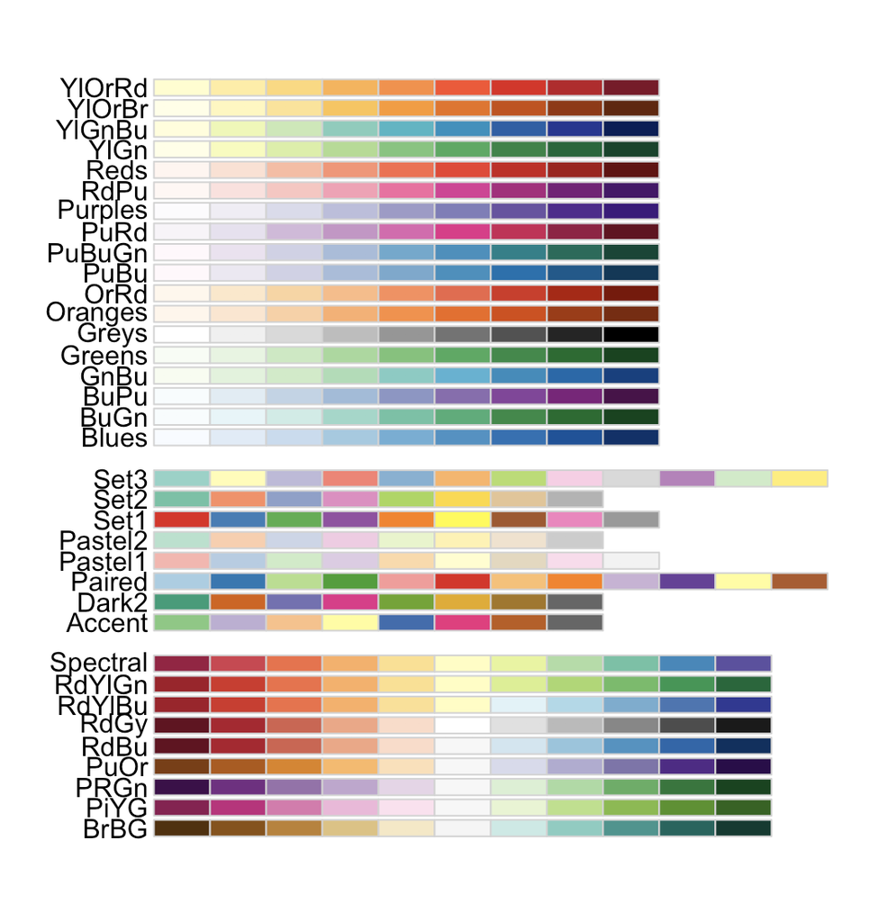

`display.brewer.all(colorblindFriendly = TRUE)` will display only colorblind friendly palettes.

- Visualize a single RColorBrewer palette by specifying its name:

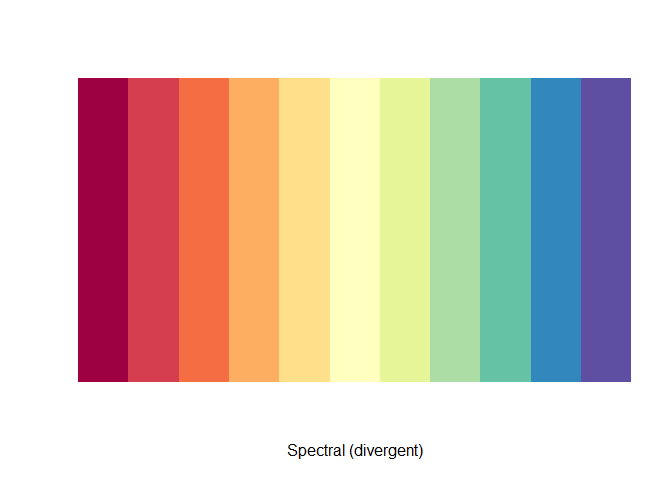

```r
# Figure 65
display.brewer.pal(11, "Spectral")
```

- Return the hexadecimal color code of the palette:

```r
brewer.pal(11, "Spectral")
```

```
##  [1] "#9E0142" "#D53E4F" "#F46D43" "#FDAE61" "#FEE08B" "#FFFFBF" "#E6F598"
##  [8] "#ABDDA4" "#66C2A5" "#3288BD" "#5E4FA2"
```

#### 2.3.8.3 Predefined Color in R

Then, there are five predefined color palettes and 657 built-in color names available in R.

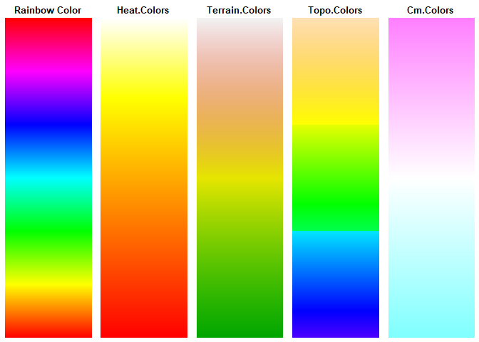

`show_col()` in **scales** package will give you a quick and dirty way to show colours in a plot.

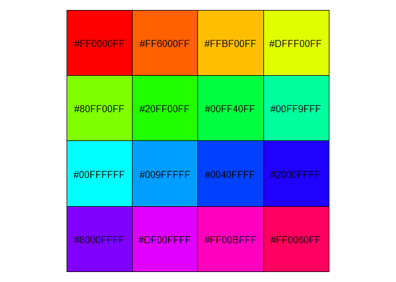

```r
# Figure 66
library(scales)
show_col(rainbow(16), labels = T)
```

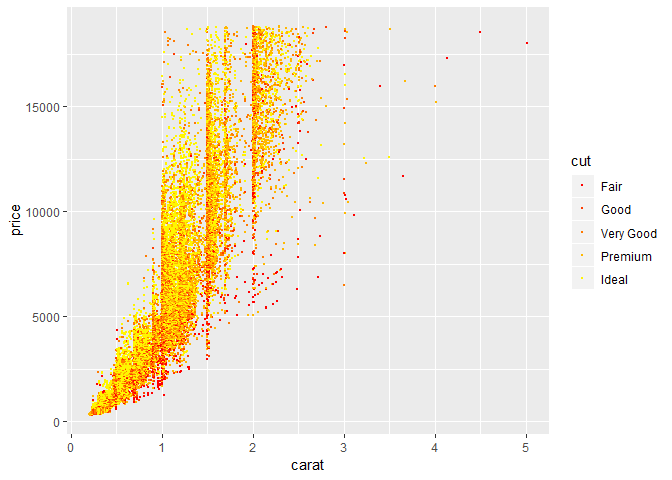

```r
# Figure 67
ggplot(diamonds, aes(carat, price, colour = cut)) +
  geom_point(size = 0.5) +
  scale_colour_manual(values = rainbow(25))
```

Because **cut** has 5 factors, in `values = rainbow(n)`, n must be greater than or equal to 5. **values** takes the first five values. Change n and you will get different beautiful plots.

The function `colors()` returns the color names, which R knows about.

```r
# Figure 68
r_color <- colors()
head(r_color)
```

```
## [1] "white"         "aliceblue"     "antiquewhite"  "antiquewhite1"
## [5] "antiquewhite2" "antiquewhite3"
```

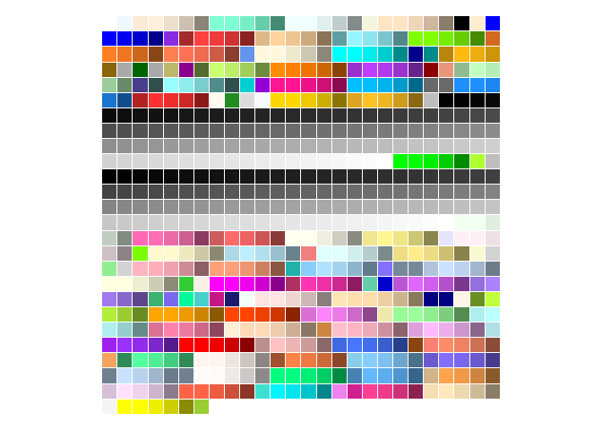

```r
# Figure 69
show_col(r_color, labels = FALSE, border = "white")
```

#### 2.3.8.4 Other Color Schemes

Finally, **ggthemes** package provides a large number of high-quality themes and color schemes. The most common schemes are economist, wsj, stata, excel, tableau and solarized.

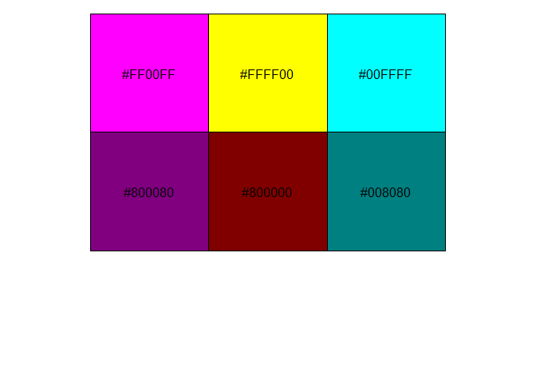

```r
library(ggthemes)
m<-excel_pal()(6)
show_col(m)
```

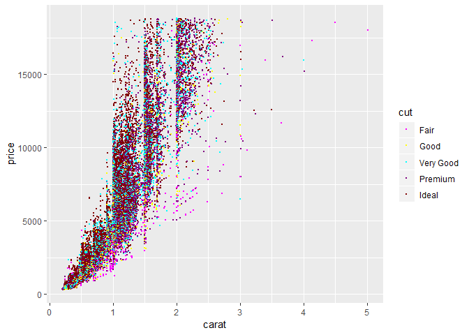

```r
# Figure 70
ggplot(diamonds, aes(carat, price, colour = cut)) +
  geom_point(size = 0.5) +
  scale_colour_excel()
```

The R package **ggsci** also contains a collection of high-quality color palettes inspired by colors used in scientific journals, data visualization libraries, and more. The color palettes are provided as ggplot2 scale functions:

- `scale_color_npg()` and `scale_fill_npg()`: Nature Publishing Group color palettes
- `scale_color_aaas()` and `scale_fill_aaas()`: American Association for the Advancement of Science color palettes
- `scale_color_lancet()` and `scale_fill_lancet()`: Lancet journal color palettes
- `scale_color_jco()` and `scale_fill_jco()`: Journal of Clinical Oncology color palettes
- `scale_color_tron()` and `scale_fill_tron()`: This palette is inspired by the colors used in Tron Legacy. It is suitable for displaying data when using a dark theme.

You can find more examples in the ggsci package vignettes.

## 2.4 Plot Examples

### 2.4.1 Time Series 1

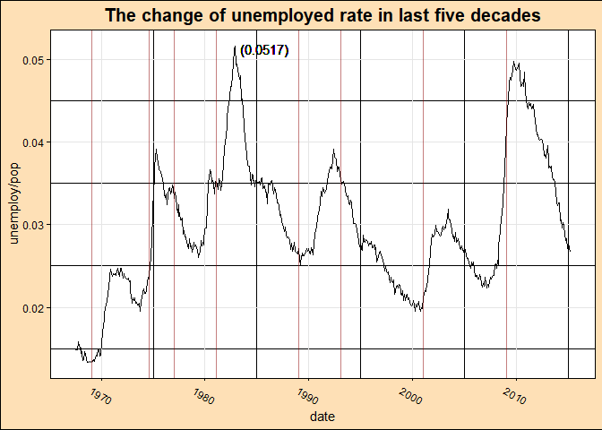

```r
# Figure 71
ggplot(economics) +
  geom_line(aes(date, unemploy/pop)) +
  labs(title = "The change of unemployed rate in last five decades") +
  theme_linedraw() +
  theme(plot.title = element_text(face = "bold", size = 15, hjust = 0.5),
        panel.grid.major = element_line(colour = "grey90", size = 0.3),
        panel.background = element_rect(fill = "white"),
        plot.background = element_rect(fill = "#FEE0B6", colour = "black"),
        axis.text.x = element_text(angle = -30, vjust = 0.5)) +
  geom_vline(xintercept = presidential$start, colour = "darkred", alpha = 0.5) +
  geom_text(x = date[which.max(unemploy/pop)], y = max(unemploy/pop),
            label = paste0("(",round(max(unemploy/pop), 4), ")"),
            vjust = 0.8, hjust = -0.1)
```

### 2.4.2 Time Series 2

**Line_Data.csv** file is the stock price data of Apple (AAPL) and Amazon (AMZN) over the past 10 years. This plot can briefly show how to deal with date type data and set appropriate coordinate axis.

```r
library(reshape2)
LineData <- read.csv("Line_Data.csv", stringsAsFactors = FALSE)
head(LineData)
```

| date | AMZN | AAPL |
| --- | --- | --- |
| 2000/1/1 | 69 | 25.94 |
| 2000/2/1 | 67 | 28.66 |
| 2000/3/1 | 55 | 33.95 |
| 2000/4/1 | 48 | 31.01 |
| 2000/5/1 | 36 | 21.00 |
| 2000/6/1 | 30 | 26.19 |

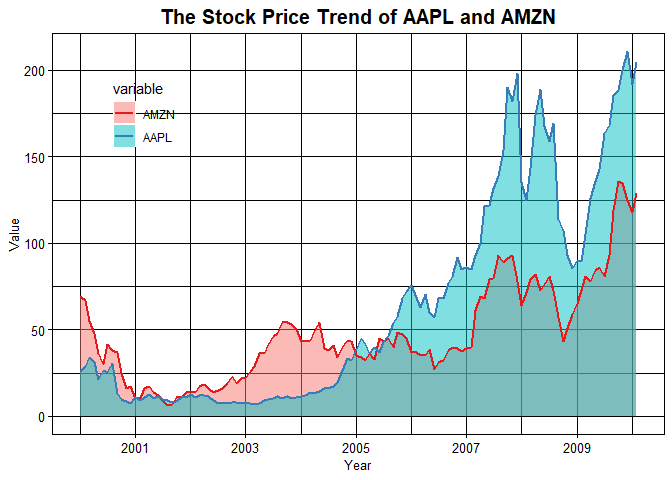

```r
# Figure 72
LineData$date <- as.Date(LineData$date)
LineData <- melt(LineData, id = "date")
ggplot(LineData, aes(x = date, y = value, group = variable)) +
  geom_area(aes(fill = variable), alpha = 0.5, position = "identity") +
  geom_line(aes(color = variable), size = 0.75) +
  scale_x_date(date_labels = "%Y", date_breaks = "2 year") +
  xlab("Year") +
  ylab("Value") +
  labs(title = "The Stock Price Trend of AAPL and AMZN") +
  theme_linedraw() +
  theme( plot.title = element_text(size = 15, face = "bold", hjust = 0.5),
         axis.title = element_text(size = 10, face = "plain", color = "black"),
         axis.text = element_text(size = 10, face = "plain", color = "black"),
         legend.position = c(0.15,0.8),
         legend.background = element_blank()) +
  scale_colour_brewer(type = "seq", palette = "Set1")
```

### 2.4.3 Scatter plot

This example describes how to create a scatter plot and add regression lines using `geom_point()` and `geom_smooth()` functions. Note that we remove confidence intervals and extend the regression lines. We also use `geom_rug()` to add marginal rugs

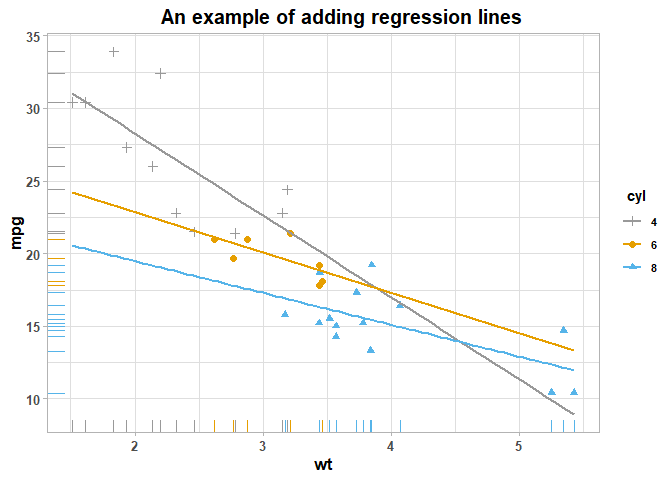

```r
# Figure 73
mtcars$cyl <- as.factor(mtcars$cyl)
ggplot(mtcars, aes(x = wt, y = mpg, color = cyl, shape = cyl)) +
  geom_point(size = 2) +
  geom_smooth(method = lm, se = FALSE, fullrange = TRUE) +
  scale_shape_manual(values = c(3, 16, 17)) +
  scale_color_manual(values = c('#999999', '#E69F00', '#56B4E9')) +
  labs(title = "An example of adding regression lines") +
  theme_light() +
  theme(plot.title = element_text(face = "bold", size = 15, hjust = 0.6),
        axis.title = element_text(face = "bold", size = 12),
        axis.text = element_text(size = 10, face= "bold"),
        legend.text = element_text(face = "bold", size = 8),
        legend.title = element_text(face = "bold"),
        legend.title.align = 0.4) +
  geom_rug()
```

### 2.4.4 Box Plot

The box plot (a.k.a. box and whisker diagram) is a standardized way of displaying the distribution of data based on the five number summary: minimum, first quartile, median, third quartile, and maximum. We estimate the fuel consumption in different brands of cars. Meanwhile, we highlight those outliers (red) and detailed data (black) to make the chart clearer.

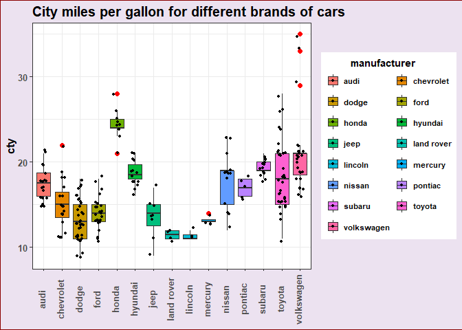

```r
# Figure 74
ggplot(mpg, aes(manufacturer, cty, fill = manufacturer)) +
  geom_boxplot(outlier.colour = "red",
               outlier.shape = 16,
               outlier.size = 2,
               notch = FALSE) +
  xlab(NULL) +
  labs(title = "City miles per gallon for different brands of cars") +
  guides(fill = guide_legend(ncol = 2, byrow = TRUE, alpha = 1)) +
  geom_jitter(shape = 16, position = position_jitter(0.2), size=1) +
  theme_bw() +
  theme(plot.title = element_text(face = "bold", colour = "black",
                                  hjust = 0, vjust = 1,
                                  size = 15),
        axis.text.x = element_text(angle = 90, vjust = 0.2),
        axis.text = element_text(size = 10, face= "bold"),
        axis.title.y= element_text(face= "bold", size = 12),
        legend.text = element_text(face = "bold", size = 8),
        legend.title = element_text(face = "bold"),
        legend.title.align = 0.4,
        legend.key.width = unit(0.5, "cm"),
        plot.background = element_rect(fill = "#ECE2F0", colour = "darkred"))
```

### 2.4.5 Faceted Plot

In the economics data, we can consider the relationship between unemployment rate and median duration from 1960s to 2010s. As we can see, there may be a linear relationship in each plot. However, the impact of duration on unemployment rate may different.

For faceting, we need to extract “year” from “year-month-date”.

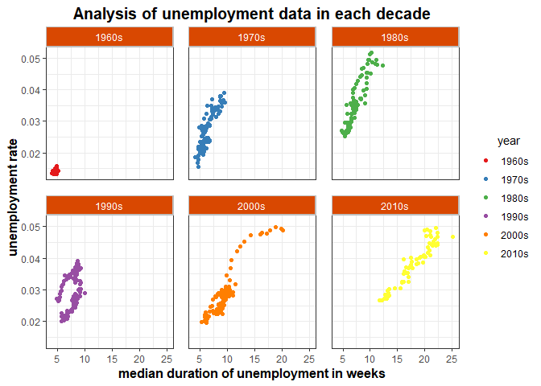

```r
# Figure 75
economics$year <- paste0(substr(economics$date,1,3),"0s")
ggplot(economics, aes(uempmed, unemploy / pop, color = year)) +
  geom_point() +
  facet_wrap(~year) +
  xlab("median duration of unemployment in weeks") +
  ylab("unemployment rate") +
  labs(title = "Analysis of unemployment data in each decade") +
  theme_bw() +
  scale_colour_brewer(type = "seq", palette = "Set1") +
  theme(plot.title = element_text(face = "bold", colour = "black",
                                  hjust = 0.5, vjust = 1, size = 15),
        panel.spacing = unit(0.2, "in"),
        strip.background = element_rect(fill = "#D94801", color = "grey", size = 1),
        strip.text = element_text(colour = "white"),
        legend.position = "right",
        panel.background = element_rect(fill = "white"),
        axis.title = element_text(face = "bold", size = 12),
        legend.title.align = 0.7)
```